# Self-reported expressibility predicts communicative success: Open dataset, validation, and simulation

Bayesian Modeling

Aleksandra Ćwiek

05 August, 2025

# 1 Introduction

This is the modeling of expressibility vs. guessability, preregistered at [AsPredicted](https://aspredicted.org/kmry-vx5s.pdf).

This script uses the output of `2_descriptive.Rmd` and produces all the values and plots reported in the paper.

# 2 Data preparation

## 2.1 Setup

```r
########## folders ##########
setwd(dirname(rstudioapi::getActiveDocumentContext()$path))

parentfolder <- dirname(getwd())

rawdata       <- paste0(parentfolder, '/rawdata/');
dataset       <- paste0(parentfolder, '/dataset/');
models        <- paste0(parentfolder, '/models/');
plots         <- paste0(parentfolder, '/plots/');
scripts       <- paste0(parentfolder, '/scripts/');

########## source file ##########

#rmarkdown::render("1_descriptive.Rmd", envir = globalenv(), clean = FALSE)

#################### packages ####################
# Data Manipulation
library(tidyverse);packageVersion("tidyverse")
```

```
## [1] '2.0.0'
```

```r
# Plotting
library(corrplot);
library(cowplot);
library(ggdist);
library(gridExtra);
library(sjPlot);
library(knitr);

# Bayesian
library(brms);
library(loo);packageVersion("loo")
```

```
## [1] '2.8.0'
```

```r
library(HDInterval);packageVersion("HDInterval")
```

```
## [1] '0.2.4'
```

```r
library(cmdstanr);
library(emmeans);packageVersion("emmeans")
```

```
## [1] '1.11.0'
```

```r
library(posterior);
library(bayesplot);
library(BayesFactor);
library(tidybayes);packageVersion("tidybayes")
```

```
## [1] '3.0.7'
```

```r
library(bayestestR);

theme_set(theme_tidybayes() + panel_border());

# use all available cores for parallel computing
options(mc.cores = parallel::detectCores());

colorBlindBlack8  <- c("#000000", "#E69F00", "#56B4E9", "#009E73",
                       "#F0E442", "#0072B2", "#D55E00", "#CC79A7")
```

## 2.2 Load in data frames

```r
# Load data frame
df <- read_csv(paste0(dataset, "df.csv"))

# Demographics
demo <- read_delim(paste0(dataset, "demo.csv"), delim = "\t")
demo$gender <- as.factor(demo$gender)

# Load concept list
concepts <- readxl::read_excel(paste0(dataset, "conceptlist_info.xlsx"))

# Load expressibility German
expr_german <- read_csv(paste0(dataset, "expressibility_german.csv"))

# Load expressibility Dutch
expr_dutch <- read_csv(paste0(dataset, "expressibility_dutch.csv"))
```

## 2.3 Helper functions

```r
# Helper function for overall back-transformation.
# Note: In our parameterization, both the mu and zoi intercepts are on the logit scale.
back_transform_zoib <- function(eta, zoi, coi = 1) {
  p_zoi <- plogis(zoi)       # back-transform the inflation parameter
  # Overall predicted value: with probability p_zoi the observation comes from the beta part (with mean plogis(eta))
  # and with probability 1-p_zoi it is inflated to coi.
  p_zoi * plogis(eta) + (1 - p_zoi) * coi
}

# Helper function for LOO:
get_save_loo <- function(model, file_name) {
  file_path <- paste0(models, file_name)
  if (!file.exists(file_path)) {
    cat("Computing LOO for", file_name, "...\n")
    loo_val <- loo(model)
    saveRDS(loo_val, file = file_path)
  } else {
    cat("Loading saved LOO for", file_name, "...\n")
    loo_val <- readRDS(file_path)
  }
  return(loo_val)
}

# Helper function for WAIC:
get_save_waic <- function(model, file_name) {
  file_path <- paste0(models, file_name)
  if (!file.exists(file_path)) {
    cat("Computing WAIC for", file_name, "...\n")
    waic_val <- waic(model)
    saveRDS(waic_val, file = file_path)
  } else {
    cat("Loading saved WAIC for", file_name, "...\n")
    waic_val <- readRDS(file_path)
  }
  return(waic_val)
}

# Log odds to probability (logistic regression intercept):
lo2p <- function(x){ o <- exp(x); return (o/(1+o));}

# Log odds to odds ratio change as percent (logistic regression slopes):
lo2or <- function(x){ o <- exp(x); if(x < 0){ return (-(1-o)) } else { return (o-1) };}

# Log odds to odds ratio change between level values (logistic regression slopes):
#lo2ps <- function(a,b){if(b > 0){ return (plogis(a+b)-plogis(a)) }else{ return (-(plogis(a)-plogis(a+b))) }}
lo2ps <- function(a,b){ plogis(a+b) - plogis(a) }

# Scientific notation using Markdown conventions (inspired from https://www.r-bloggers.com/2015/03/scientific-notation-for-rlatex/):
scinot <- function(xs, digits=2, pvalue=TRUE)
{
  scinot1 <- function(x)
  {
    sign <- "";
    if(x < 0)
    {
      sign <- "-";
      x <- -x;
    }
    exponent <- floor(log10(x));
    if(exponent && pvalue && exponent < -3)
    {
      xx <- round(x / 10^exponent, digits=digits);
      e <- paste0("×10^", round(exponent,0), "^");
    } else
    {
      xx <- round(x, digits=digits+1);
      e <- "";
    }
    paste0(sign, xx, e);
  }
  vapply(xs, scinot1, character(1));
}

# Escape * in a string:
escstar <- function(s)
{
  gsub("*", "\\*", s, fixed=TRUE);
}

# Figure and Table caption adapted from https://stackoverflow.com/questions/37116632/rmarkdown-html-number-figures:
outputFormat = opts_knit$get("rmarkdown.pandoc.to"); # determine the output format of the document
if( is.null(outputFormat) ) outputFormat = ""; # probably not run within knittr
capTabNo = 1; capFigNo = 1; # figure and table caption numbering, for HTML do it manually
#Function to add the Table Number
capTab = function(x)
{
  if(outputFormat == 'html'){
    x = paste0("**Table ",capTabNo,".** ",x,"")
    capTabNo <<- capTabNo + 1
  }; x
}
#Function to add the Figure Number
capFig = function(x, show_R_version=TRUE, show_package_versions=NULL, is_map=FALSE)
{
  if(outputFormat == 'html')
  {
    x <- paste0("**Figure ",capFigNo,".** ",x,"");
    if( show_R_version || (!is.null(show_package_versions) && length(show_package_versions) > 0) )
    {
      x <- paste0(x, " Figure generated using ");
      if( show_R_version ) x <- paste0(x, stringr::str_replace(R.version.string, stringr::fixed("R "), "[`R`](https://www.r-project.org/) "));
      if( !is.null(show_package_versions) && length(show_package_versions) > 0 )
      {
        x <- paste0(x, ifelse( show_R_version, " and ", " "));
        x <- paste0(x, ifelse( length(show_package_versions) > 1, "packages ", "package "));
        x <- paste0(x, paste0(vapply(show_package_versions, function(x) paste0("`",x,"`", " (version ", packageVersion(x),")"), character(1)), collapse=", "), ".");
      }
      if( is_map ) x <- paste0(x, " Maps are using public domain data from the [Natural Earth project](https://www.naturalearthdata.com/) as provided by the `R` package `maps`.");
    }
    capFigNo <<- capFigNo + 1;
  };
  x;
}
```

## 2.4 Information from the preregistration

We will use weakly informative priors for the fixed and random effect, just informing the models about the ranges of the scale of the outcome variable.

The `guessability_match` is a categorical variable and will be coded as `0` for incorrect guess and `1` for correct guess. The `guessability_similarity` will be a continuous variable expressing the cosine similarity of guesser’s answer to target (estimated using ConceptNet). The `N_repetition` encompasses the data from the second half of the experiment only (where participants could repeat the production) and represents a number of repetitions until the production was correctly guessed or until a maximum of three productions was reached. The `experiment_part` is a categorical variable coded as `1` and `2`, for the respective halves of the experiment. `Modality` is a categorical variable with three levels: `combined`, `gesture`, and `vocalization`.

For `N_repetion`, we will start with a Poisson model and check residuals as well as compare the mean and variance. If overdispersion is present, we will switch to negbinomial family.

For the continuous `guessability_similarity` outcome variable, we will test the best fitting family by inspecting the distribution of the outcome variable. We do this because the data might not be normally distributed. We will choose an optimal family among gamma, lognormal, or skew_normal if the normal is inappropriate.

# 3 Prepare data

## 3.1 Sample size

Calculate the effective sample size for modeling.

There are 142 speakers from 71 dyads.

There are a total of 8989 novel productions, from that, 2968 in experiment part 1 and 6021 in experiment part 2.

In experiment part 2, there are 2982 data points of the very first production, 1787 data points of the first repetition/correction (i.e., second production), and 1252 data points of the second repetition/correction (i.e., third production).

Across modalities, there are 2789 productions in combined (994 in part 1 vs. 1795 in part 2), 2799 in gesture (980 in part 1 vs. 1819 in part 2), and 3401 in vocal modality (994 in part 1 vs. 2407 in part 2).

## 3.2 Cosine similarity

Cosine similarity is inherently on -1 to 1 scale. As provided [here](https://github.com/deepinsight/insightface/issues/917):

> Cosine similarity is like an inner product. If angle between two vector is larger than 90 degree, the value is negative, and that means that two faces(features) are clearly distinguishable.

Meaning that a negative value is provided for concepts that are clearly different (i.e., not confusable).

In order to be able to model the values with a wider choice of families (including zero-one inflated beta), we transformed the cosine similarity with

`(df$cosine_similarity + 1) / 2`

This transformation resulted in data distributed in the following way

```r
summary(df$cosine_similarity)
```

```
##    Min. 1st Qu.  Median    Mean 3rd Qu.    Max.    NA's
##  0.4500  0.5800  0.7080  0.7605  1.0000  1.0000       7
```

Below, we break down the missing values and look at data distribution to choose an appropriate family.

```r
# Total missing values for cosine_similarity and its percentage
cat("Total missing values for cosine_similarity: ", sum(is.na(df$cosine_similarity)), "\n")
```

```
## Total missing values for cosine_similarity:  7
```

```r
cat("Percentage missing: ", round(100 * sum(is.na(df$cosine_similarity)) / nrow(df), 1), "%\n\n")
```

```
## Percentage missing:  0.1 %
```

```r
# Breakdown by modality:
cat("Missing values by modality:\n")
```

```
## Missing values by modality:
```

```r
df %>%
  group_by(modality) %>%
  summarise(
    missing = sum(is.na(cosine_similarity)),
    total = n(),
    percent_missing = round(100 * sum(is.na(cosine_similarity)) / n(), 1)
  ) %>%
  print(n = Inf)
```

```
## # A tibble: 3 × 4
##   modality missing total percent_missing
##   <chr>      <int> <int>           <dbl>
## 1 combined       2  2789             0.1
## 2 gesture        2  2799             0.1
## 3 vocal          3  3401             0.1
```

```r
cat("\nBreakdown by experiment part (exp_part):\n")
```

```
##
## Breakdown by experiment part (exp_part):
```

```r
df %>%
  group_by(exp_part) %>%
  summarise(
    missing = sum(is.na(cosine_similarity)),
    total = n(),
    percent_missing = round(100 * sum(is.na(cosine_similarity)) / n(), 1)
  ) %>%
  print(n = Inf)
```

```
## # A tibble: 2 × 4
##   exp_part missing total percent_missing
##      <dbl>   <int> <int>           <dbl>
## 1        1       0  2968             0
## 2        2       7  6021             0.1
```

```r
cat("\nBreakdown by repetition (correction):\n")
```

```
##
## Breakdown by repetition (correction):
```

```r
df %>%
  group_by(correction) %>%
  summarise(
    missing = sum(is.na(cosine_similarity)),
    total = n(),
    percent_missing = round(100 * sum(is.na(cosine_similarity)) / n(), 1)
  ) %>%
  print(n = Inf)
```

```
## # A tibble: 3 × 4
##   correction missing total percent_missing
##        <dbl>   <int> <int>           <dbl>
## 1          0       4  5950             0.1
## 2          1       1  1787             0.1
## 3          2       2  1252             0.2
```

Let us inspect the distribution of cosine similarity

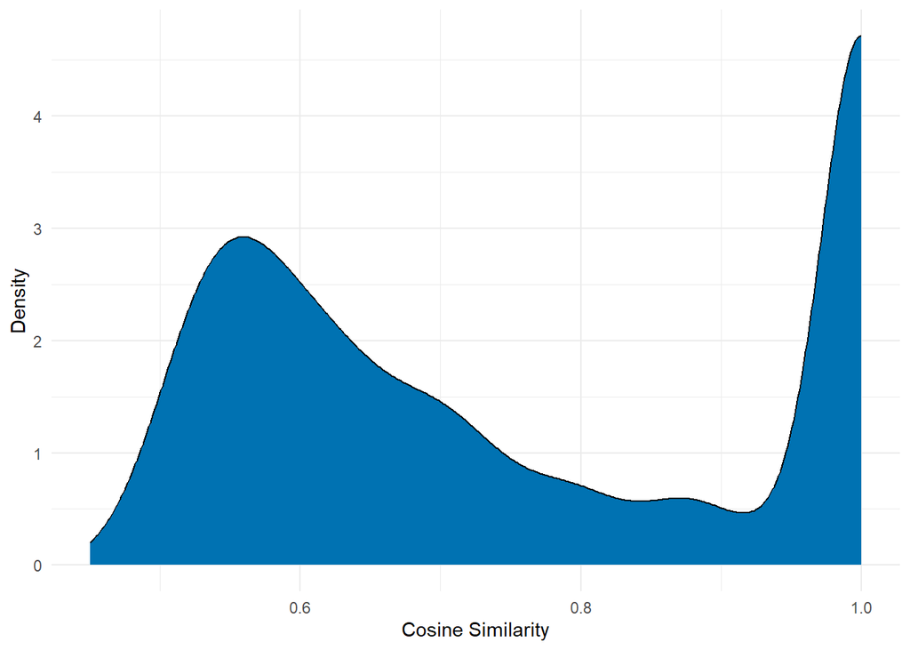

```r
ggplot(df, aes(x = cosine_similarity)) +
  geom_density(fill = colorBlindBlack8[6]) +
  theme_minimal() +
  labs(x = "Cosine Similarity", y = "Density")
```

```r
moments::skewness(df$cosine_similarity)
```

```
## [1] NA
```

The distribution is fairly bimodal. The peak at 1 results from obvious 100% match cases that correspond to binary guess = 1. Then there is another peak around 0.5 which results from non-ideal guesses.

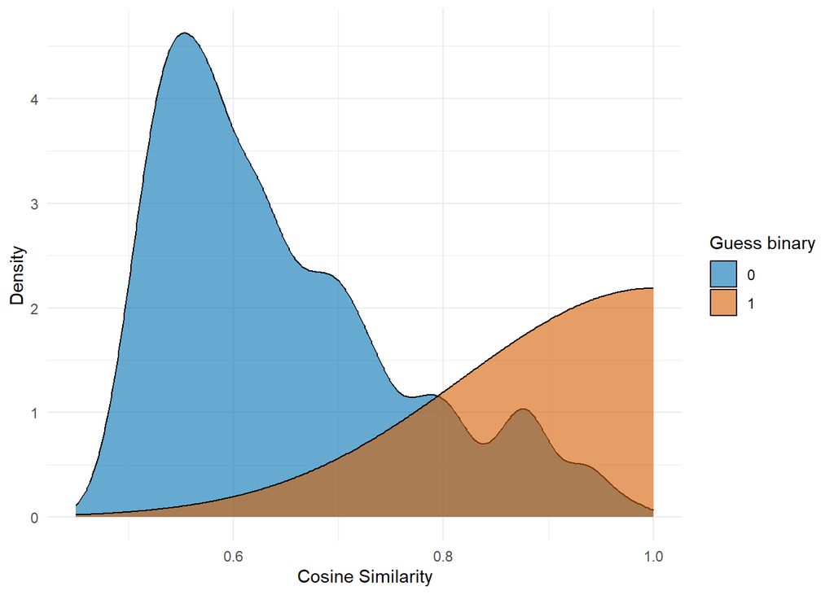

```r
ggplot(df, aes(x = cosine_similarity, fill = factor(guess_binary))) +
  geom_density(alpha = 0.6) +  # alpha to make the fill slightly transparent
  theme_minimal() +
  labs(x = "Cosine Similarity", y = "Density", fill = "Guess binary") +
  scale_fill_manual(values = c(colorBlindBlack8[6], colorBlindBlack8[7]))
```

The family that will fit this data best is one-inflated beta. In the brms framework, we don’t have a separate family for one‐inflated beta, but we can force it by fixing the zero‐inflation parameter (zoi) to 1 (or nearly 1). That way, the model assumes no probability mass at 0, and all of the inflation is allocated to the one‐inflation (coi) component.

Let’s compute the summary statistics of cosine similarity grouped by guess_binary

```r
df %>%
  group_by(guess_binary) %>%
  summarise(
    mean_cosine_similarity = mean(cosine_similarity, na.rm = TRUE),
    sd_cosine_similarity = sd(cosine_similarity, na.rm = TRUE),
    min_cosine_similarity = min(cosine_similarity, na.rm = TRUE),
    max_cosine_similarity = max(cosine_similarity, na.rm = TRUE),
    median_cosine_similarity = median(cosine_similarity, na.rm = TRUE),
    n = n()  # Count of observations
  )
```

| guess_binary | mean_cosine_similarity | sd_cosine_similarity | min_cosine_similarity | max_cosine_similarity | median_cosine_similarity | n |
| --- | --- | --- | --- | --- | --- | --- |
| 0 | 0.6446218 | 0.116018 | 0.45 | 1 | 0.616 | 6061 |
| 1 | 1.0000000 | 0.000000 | 1.00 | 1 | 1.000 | 2928 |

## 3.3 Variables

Our hypotheses revolve around a set of fixed and random predictors for different outcome variables.

The outcome variables in the data frame `df` are:

- `guess_binary`: a *binary categorical* variable coded as `0` for incorrect guess and `1` for correct guess
- `cosine_similarity`: a *continuous* variable expressing the cosine similarity of guesser’s answer to target (estimated using ConceptNet)
- `correction`: a *categorical* variable with three levels `0` for the first production, `1` for the first correction, `2` for the second correction

The predictor variables in the data frame `df` are:

- `expressibility`: a *continuous* variable expressing the rated posterior expressibility, set for each concept in each modality
- `exp_part`: a *binary categorical* variable coded as `1` for the first experiment part and `2` for the second experiment part
- `modality`: a *categorical* variable with three levels `combined` for both gesture and vocal, `gesture` for gesture only, `vocal` for vocal only

The random variables in the data frame `df` are:

- `concept`: a *categorical* variable for individual concepts (a total of odor, to breathe, to eat, to swim, to throw, water, wind, fire, old, strong, sweet, to burn, to hear, to smell, buzz, squeak, thunder, to catch, to chew, to fly, to stand, big, bitter, cold, dog, egg, female, to crawl, cat, dead, fast, snake, thick, to cry, to drink, child, far, happy, horn, hot, salt, sick, fish, high, rain, sad, slow, to know, to run, heavy, not, scared, silent, tail, to fall, to lick, I, lightning, small, to hit, to sleep, to suck, to vomit, angry, disgusted, good, loud, male, to bite, to laugh, bird, fly, maybe, sharp, sour, to hunt, to jump, mountain, to blow, to fight, to give, to growl, to walk, to whisper)
- `dyad`: a *categorical* variable for individual dyads (a total of 10, 11, 12, 13, 14, 15, 16, 17, 18, 19, 1, 20, 21, 22, 23, 24, 25, 26, 27, 28, 29, 2, 30, 31, 32, 33, 34, 35, 36, 37, 38, 39, 3, 40, 41, 42, 43, 44, 45, 46, 47, 48, 49, 4, 50, 51, 52, 53, 54, 55, 56, 57, 58, 59, 5, 60, 61, 62, 63, 64, 65, 66, 67, 69, 6, 70, 71, 72, 7, 8, 9)
- `participant_ID` (nested within `dyad`): a *categorical* variable for individual participants (a total of 1, 2, 3, 4, 5, 6, 7, 8, 9, 10, 11, 12, 13, 14, 15, 16, 17, 18, 19, 20, 21, 22, 23, 24, 25, 26, 27, 28, 29, 30, 31, 32, 33, 34, 35, 36, 37, 38, 39, 40, 41, 42, 43, 44, 45, 46, 47, 48, 49, 50, 51, 52, 53, 54, 55, 56, 57, 58, 59, 60, 61, 62, 63, 64, 65, 66, 67, 68, 69, 70, 71, 72, 73, 74, 75, 76, 77, 78, 79, 80, 81, 82, 83, 84, 85, 86, 87, 88, 89, 90, 91, 92, 93, 94, 95, 96, 97, 98, 99, 100, 101, 102, 103, 104, 105, 106, 107, 108, 109, 110, 111, 112, 113, 114, 115, 116, 117, 118, 119, 120, 121, 122, 123, 124, 125, 126, 127, 128, 129, 130, 131, 132, 133, 134, 135, 136, 137, 138, 139, 140, 141, 142)

Preparing the variables

```r
# Outcome variables
#df$guess_binary <- factor(df$guess_binary, levels = c("0", "1")); contrasts(df$guess_binary) <- c(-0.5, +0.5)
## 'cosine_similarity' is continuous, no need to transform it
#df$correction <- factor(df$correction, levels = c("0", "1", "2"))

# Predictor variables
## 'expressibility' is continuous, no transformation needed
df$exp_part <- factor(df$exp_part, levels = c("1", "2")); contrasts(df$exp_part) <- c(-0.5, +0.5)
df$modality <- factor(df$modality, levels = c("combined", "gesture", "vocal"))

# Random variables
df$concept <- factor(df$concept)
df$dyad <- factor(df$dyad)
df$participant_ID <- factor(df$participant_ID)


# Check the balance between the levels

df %>% count(guess_binary) %>% mutate(prop = paste0(round(100* n / sum(n),1),"%"))
```

| guess_binary | n | prop |
| --- | --- | --- |
| 0 | 6061 | 67.4% |
| 1 | 2928 | 32.6% |

```r
# imbalanced 0: 67.5%, 1: 32.5%

df %>% count(correction) %>% mutate(prop = paste0(round(100* n / sum(n),1),"%"))
```

| correction | n | prop |
| --- | --- | --- |
| 0 | 5950 | 66.2% |
| 1 | 1787 | 19.9% |
| 2 | 1252 | 13.9% |

```r
# imbalanced 0: 66.2%, 1: 19.9%, 2: 13.9%

df %>% count(exp_part) %>% mutate(prop = paste0(round(100* n / sum(n),1),"%"))
```

| exp_part | n | prop |
| --- | --- | --- |
| 1 | 2968 | 33% |
| 2 | 6021 | 67% |

```r
# imbalanced 1: 33%, 2: 67%

df %>% count(modality) %>% mutate(prop = paste0(round(100* n / sum(n),1),"%"))
```

| modality | n | prop |
| --- | --- | --- |
| combined | 2789 | 31% |
| gesture | 2799 | 31.1% |
| vocal | 3401 | 37.8% |

```r
# pretty balanced, combined: 31%, gesture: 31.1%, vocal: 37.9%

# Random variables just if someone is interested in checking
# df %>% count(concept) %>% mutate(prop = paste0(round(100* n / sum(n),1),"%"))
# df %>% count(dyad) %>% mutate(prop = paste0(round(100* n / sum(n),1),"%"))
# df %>% count(participant_ID) %>% mutate(prop = paste0(round(100* n / sum(n),1),"%"))
```

# 4 Intercept-only guessability

## 4.1 Guess similarity

Preregistered model:

`guessability_similarity ~ 1 + (1 | dyad/participant) + (1 | concept)`

### 4.1.1 Model

Now, let’s build the intercept-only model for the continuous outcome, cosine_similarity. The model uses the same random effects structure. Because of the data distribution, we use a zero-one inflated beta model minimizing the zoi component.

#### 4.1.1.1 Best-fit

##### 4.1.1.1.1 Nested

With priors for ZOIB

```r
mdl_null_similarity_nested_prior <- readRDS(paste0(models, "mdl_null_similarity_nested_prior.rds"))
```

Without priors for ZOIB

```r
mdl_null_similarity_nested <- brm(
  bf(
    cosine_similarity ~ 1 + (1 | dyad/participant_ID) + (1 | concept),
    phi ~ 1,
    zoi ~ 1,
    coi ~ 1
  ),
  data = df,
  family = zero_one_inflated_beta(),
  prior = c(
    # Priors for the main (mu) component:
    prior(normal(0, 5), class = "Intercept"),
    prior(normal(0, 2), class = "sd")#,
    # Prior for the phi parameter (precision)
    #prior(normal(0, 5), class = "Intercept", dpar = "phi"),
    # Force zoi to be essentially 1, meaning P(y = 0) ~ 0:
    #prior(normal(10, 0.001), class = "Intercept", dpar = "zoi"),
    # A neutral prior for coi: centered at 0 (which implies plogis(0)=0.5) with SD=2.
    #prior(normal(0, 2), class = "Intercept", dpar = "coi")
  ),
  cores = 4,
  chains = 4,
  iter = 10000,
  warmup = 4000,
  seed = 17,
  control = list(max_treedepth = 12, adapt_delta = 0.99),
  file = paste0(models, "mdl_null_similarity_nested.rds")
)

# if we need to compress the model more
#saveRDS(mdl_null_similarity_nested, file = paste0(models, "mdl_null_similarity_nested.rds"), compress = "xz")

mdl_null_similarity_nested <- readRDS(paste0(models, "mdl_null_similarity_nested.rds"))
```

##### 4.1.1.1.2 No nesting

```r
mdl_null_similarity_simple <- readRDS(paste0(models, "mdl_null_similarity_simple.rds"))
```

##### 4.1.1.1.3 Compare

```r
mdl_null_similarity_nested_prior
```

```
##  Family: zero_one_inflated_beta
##   Links: mu = logit; phi = log; zoi = logit; coi = logit
## Formula: cosine_similarity ~ 1 + (1 | dyad/participant_ID) + (1 | concept)
##          phi ~ 1
##          zoi ~ 1
##          coi ~ 1
##    Data: df (Number of observations: 8982)
##   Draws: 4 chains, each with iter = 10000; warmup = 4000; thin = 1;
##          total post-warmup draws = 24000
##
## Multilevel Hyperparameters:
## ~concept (Number of levels: 84)
##               Estimate Est.Error l-95% CI u-95% CI Rhat Bulk_ESS Tail_ESS
## sd(Intercept)     0.30      0.03     0.26     0.36 1.00     2676     4874
##
## ~dyad (Number of levels: 71)
##               Estimate Est.Error l-95% CI u-95% CI Rhat Bulk_ESS Tail_ESS
## sd(Intercept)     0.02      0.01     0.00     0.05 1.00     3557     6580
##
## ~dyad:participant_ID (Number of levels: 142)
##               Estimate Est.Error l-95% CI u-95% CI Rhat Bulk_ESS Tail_ESS
## sd(Intercept)     0.05      0.01     0.02     0.07 1.00     3911     3500
##
## Regression Coefficients:
##               Estimate Est.Error l-95% CI u-95% CI Rhat Bulk_ESS Tail_ESS
## Intercept         0.65      0.03     0.59     0.72 1.00     1386     2862
## phi_Intercept     2.86      0.02     2.82     2.89 1.00    21804    17977
## zoi_Intercept     9.99      0.00     9.99    10.00 1.00    53034    15393
## coi_Intercept     7.58      0.75     6.34     9.25 1.00    24314    13631
##
## Draws were sampled using sampling(NUTS). For each parameter, Bulk_ESS
## and Tail_ESS are effective sample size measures, and Rhat is the potential
## scale reduction factor on split chains (at convergence, Rhat = 1).
```

```r
mdl_null_similarity_nested
```

```
##  Family: zero_one_inflated_beta
##   Links: mu = logit; phi = log; zoi = logit; coi = logit
## Formula: cosine_similarity ~ 1 + (1 | dyad/participant_ID) + (1 | concept)
##          phi ~ 1
##          zoi ~ 1
##          coi ~ 1
##    Data: df (Number of observations: 8982)
##   Draws: 4 chains, each with iter = 10000; warmup = 4000; thin = 1;
##          total post-warmup draws = 24000
##
## Multilevel Hyperparameters:
## ~concept (Number of levels: 84)
##               Estimate Est.Error l-95% CI u-95% CI Rhat Bulk_ESS Tail_ESS
## sd(Intercept)     0.30      0.03     0.25     0.35 1.00     3508     6519
##
## ~dyad (Number of levels: 71)
##               Estimate Est.Error l-95% CI u-95% CI Rhat Bulk_ESS Tail_ESS
## sd(Intercept)     0.02      0.01     0.00     0.04 1.00     4162     9146
##
## ~dyad:participant_ID (Number of levels: 142)
##               Estimate Est.Error l-95% CI u-95% CI Rhat Bulk_ESS Tail_ESS
## sd(Intercept)     0.05      0.01     0.02     0.07 1.00     3970     3203
##
## Regression Coefficients:
##               Estimate Est.Error l-95% CI u-95% CI Rhat Bulk_ESS Tail_ESS
## Intercept         0.65      0.03     0.58     0.72 1.00     1589     3175
## phi_Intercept     2.86      0.02     2.82     2.89 1.00    28099    17549
## zoi_Intercept    -0.73      0.02    -0.77    -0.68 1.00    44790    17156
## coi_Intercept     8.55      1.27     6.69    11.68 1.00    24854    11883
##
## Draws were sampled using sampling(NUTS). For each parameter, Bulk_ESS
## and Tail_ESS are effective sample size measures, and Rhat is the potential
## scale reduction factor on split chains (at convergence, Rhat = 1).
```

```r
mdl_null_similarity_simple
```

```
##  Family: zero_one_inflated_beta
##   Links: mu = logit; phi = log; zoi = logit; coi = logit
## Formula: cosine_similarity ~ 1 + (1 | dyad) + (1 | concept)
##          phi ~ 1
##          zoi ~ 1
##          coi ~ 1
##    Data: df (Number of observations: 8982)
##   Draws: 4 chains, each with iter = 10000; warmup = 4000; thin = 1;
##          total post-warmup draws = 24000
##
## Multilevel Hyperparameters:
## ~concept (Number of levels: 84)
##               Estimate Est.Error l-95% CI u-95% CI Rhat Bulk_ESS Tail_ESS
## sd(Intercept)     0.30      0.03     0.25     0.35 1.00     3333     6520
##
## ~dyad (Number of levels: 71)
##               Estimate Est.Error l-95% CI u-95% CI Rhat Bulk_ESS Tail_ESS
## sd(Intercept)     0.03      0.01     0.01     0.05 1.00     5709     4405
##
## Regression Coefficients:
##               Estimate Est.Error l-95% CI u-95% CI Rhat Bulk_ESS Tail_ESS
## Intercept         0.65      0.03     0.58     0.72 1.01     1585     3310
## phi_Intercept     2.85      0.02     2.82     2.88 1.00    38377    17948
## zoi_Intercept    -0.73      0.02    -0.77    -0.68 1.00    44512    17759
## coi_Intercept     8.56      1.29     6.67    11.66 1.00    29089    12190
##
## Draws were sampled using sampling(NUTS). For each parameter, Bulk_ESS
## and Tail_ESS are effective sample size measures, and Rhat is the potential
## scale reduction factor on split chains (at convergence, Rhat = 1).
```

Calculate R².

```
##        Estimate    Est.Error         Q2.5       Q97.5
## R2 2.201668e-10 1.071349e-11 1.996594e-10 2.41653e-10
```

```
##      Estimate   Est.Error       Q2.5      Q97.5
## R2 0.04916816 0.002428616 0.04445825 0.05403211
```

```
##      Estimate   Est.Error       Q2.5      Q97.5
## R2 0.04822377 0.002378273 0.04366248 0.05305569
```

All the models are very weak in explaining the data, however the one with the ZOIB prior `mdl_null_similarity_nested_prior` is extremely weak. One argument not to use the priors for family-specific parameters.

```r
# Compute and save LOO for both models:
loo_nested_prior  <- get_save_loo(mdl_null_similarity_nested_prior, "mdl_null_similarity_nested_prior_loo.rds")
```

```
## Loading saved LOO for mdl_null_similarity_nested_prior_loo.rds ...
```

```r
loo_nested  <- get_save_loo(mdl_null_similarity_nested, "mdl_null_similarity_nested_loo.rds")
```

```
## Loading saved LOO for mdl_null_similarity_nested_loo.rds ...
```

```r
loo_simple  <- get_save_loo(mdl_null_similarity_simple, "mdl_null_similarity_simple_loo.rds")
```

```
## Loading saved LOO for mdl_null_similarity_simple_loo.rds ...
```

```r
# Compute and save WAIC for both models:
waic_nested_prior <- get_save_waic(mdl_null_similarity_nested_prior, "mdl_null_similarity_nested_prior_waic.rds")
```

```
## Loading saved WAIC for mdl_null_similarity_nested_prior_waic.rds ...
```

```r
waic_nested <- get_save_waic(mdl_null_similarity_nested, "mdl_null_similarity_nested_waic.rds")
```

```
## Loading saved WAIC for mdl_null_similarity_nested_waic.rds ...
```

```r
waic_simple <- get_save_waic(mdl_null_similarity_simple, "mdl_null_similarity_simple_waic.rds")
```

```
## Loading saved WAIC for mdl_null_similarity_simple_waic.rds ...
```

```r
# Compare LOO and WAIC between models:
print(loo_compare(loo_nested_prior, loo_nested))
```

```
##       elpd_diff se_diff
## model      0.0       0.0
## model -54812.0     476.3
```

```r
print(loo_compare(loo_nested, loo_simple))
```

```
##       elpd_diff se_diff
## model  0.0       0.0
## model -5.9       3.1
```

```r
print(loo_compare(loo_nested_prior, loo_nested, loo_simple))
```

```
##       elpd_diff se_diff
## model      0.0       0.0
## model     -5.9       3.1
## model -54812.0     476.3
```

```r
print(loo_nested_prior)
```

```
##
## Computed from 24000 by 8982 log-likelihood matrix.
##
##          Estimate    SE
## elpd_loo -55708.6 414.1
## p_loo       140.7   4.9
## looic    111417.3 828.2
## ------
## MCSE of elpd_loo is 0.1.
## MCSE and ESS estimates assume MCMC draws (r_eff in [0.5, 1.6]).
##
## All Pareto k estimates are good (k < 0.7).
## See help('pareto-k-diagnostic') for details.
```

```r
print(loo_nested)
```

```
##
## Computed from 24000 by 8982 log-likelihood matrix.
##
##          Estimate    SE
## elpd_loo   -896.6  93.6
## p_loo       141.7   4.9
## looic      1793.3 187.1
## ------
## MCSE of elpd_loo is 0.1.
## MCSE and ESS estimates assume MCMC draws (r_eff in [0.4, 2.0]).
##
## All Pareto k estimates are good (k < 0.7).
## See help('pareto-k-diagnostic') for details.
```

```r
print(loo_simple)
```

```
##
## Computed from 24000 by 8982 log-likelihood matrix.
##
##          Estimate    SE
## elpd_loo   -902.6  93.7
## p_loo       116.0   4.2
## looic      1805.1 187.4
## ------
## MCSE of elpd_loo is 0.1.
## MCSE and ESS estimates assume MCMC draws (r_eff in [0.4, 2.3]).
##
## All Pareto k estimates are good (k < 0.7).
## See help('pareto-k-diagnostic') for details.
```

```r
print(waic_nested)
```

```
##
## Computed from 24000 by 8982 log-likelihood matrix.
##
##           Estimate    SE
## elpd_waic   -896.4  93.6
## p_waic       141.5   4.9
## waic        1792.9 187.1
##
## 33 (0.4%) p_waic estimates greater than 0.4. We recommend trying loo instead.
```

```r
print(waic_simple)
```

```
##
## Computed from 24000 by 8982 log-likelihood matrix.
##
##           Estimate    SE
## elpd_waic   -902.4  93.7
## p_waic       115.9   4.2
## waic        1804.8 187.4
##
## 19 (0.2%) p_waic estimates greater than 0.4. We recommend trying loo instead.
```

In light of these results, we have decided to proceed **without the explicit ZOIB priors and without the additional nesting**, the latter contrary to our preregistration. The simpler model not only avoids potential overparameterization and convergence issues but also yields nearly identical predictive performance. This choice adheres to the principle of parsimony while maintaining transparency about our statistical decisions.

### 4.1.2 Best-fit: “Simple”; no ZOIB priors, no nesting

**Intercept-only model for cosine similariy**

```
##      Estimate   Est.Error       Q2.5      Q97.5
## R2 0.04822377 0.002378273 0.04366248 0.05305569
```

R^2 is 0.0482238 suggesting that 4.8223769% of the variance in the outcome variable is explained by the model. This value is very low.

**Diagnostic plots**:

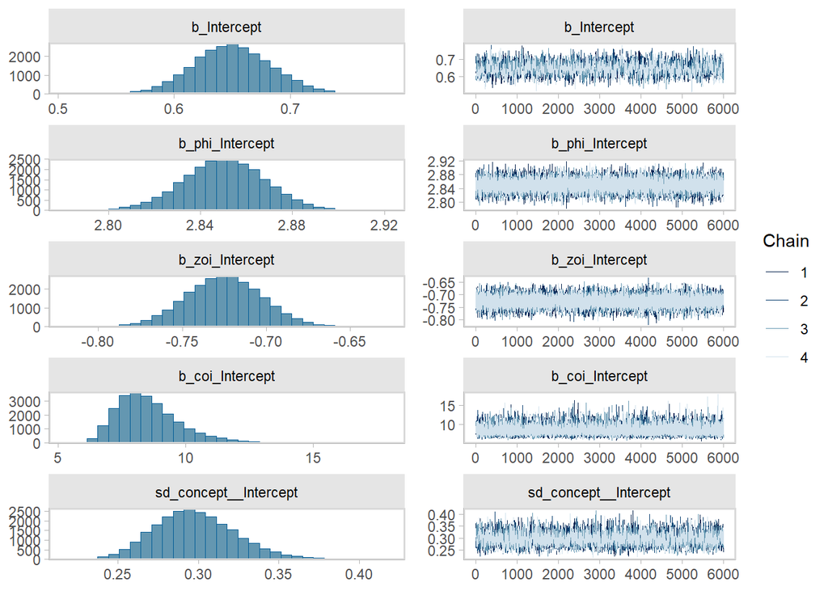

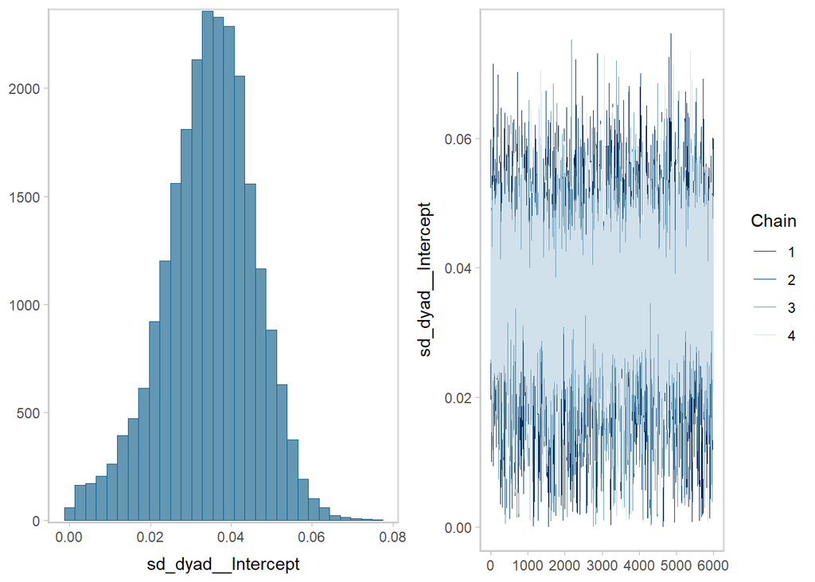

```r
plot(mdl_null_similarity_simple)
```

**Convergence**: All convergence diagnostics are good (Rhat ≤ 1.01).

```r
summary(mdl_null_similarity_simple)
```

```
##  Family: zero_one_inflated_beta
##   Links: mu = logit; phi = log; zoi = logit; coi = logit
## Formula: cosine_similarity ~ 1 + (1 | dyad) + (1 | concept)
##          phi ~ 1
##          zoi ~ 1
##          coi ~ 1
##    Data: df (Number of observations: 8982)
##   Draws: 4 chains, each with iter = 10000; warmup = 4000; thin = 1;
##          total post-warmup draws = 24000
##
## Multilevel Hyperparameters:
## ~concept (Number of levels: 84)
##               Estimate Est.Error l-95% CI u-95% CI Rhat Bulk_ESS Tail_ESS
## sd(Intercept)     0.30      0.03     0.25     0.35 1.00     3333     6520
##
## ~dyad (Number of levels: 71)
##               Estimate Est.Error l-95% CI u-95% CI Rhat Bulk_ESS Tail_ESS
## sd(Intercept)     0.03      0.01     0.01     0.05 1.00     5709     4405
##
## Regression Coefficients:
##               Estimate Est.Error l-95% CI u-95% CI Rhat Bulk_ESS Tail_ESS
## Intercept         0.65      0.03     0.58     0.72 1.01     1585     3310
## phi_Intercept     2.85      0.02     2.82     2.88 1.00    38377    17948
## zoi_Intercept    -0.73      0.02    -0.77    -0.68 1.00    44512    17759
## coi_Intercept     8.56      1.29     6.67    11.66 1.00    29089    12190
##
## Draws were sampled using sampling(NUTS). For each parameter, Bulk_ESS
## and Tail_ESS are effective sample size measures, and Rhat is the potential
## scale reduction factor on split chains (at convergence, Rhat = 1).
```

```
## No divergences to plot.
```

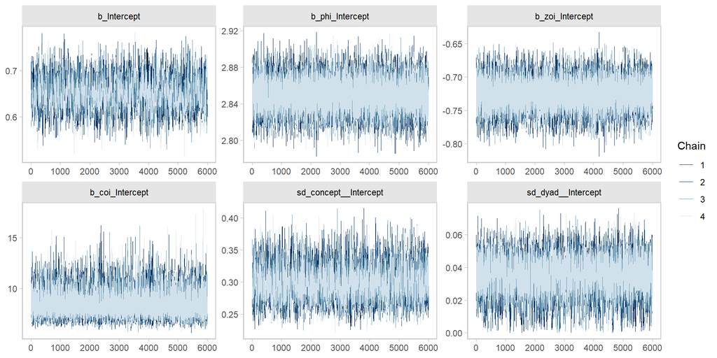

**Figure 1.** Trace of the fitting process. Figure generated using [`R`](https://www.r-project.org/) version 4.4.1 (2024-06-14 ucrt)

```r
mcmc_plot(mdl_null_similarity_simple, type="trace");
```

**Posterior predictive checks**: Modeling the density of the bimodal distribution is far from ideal.

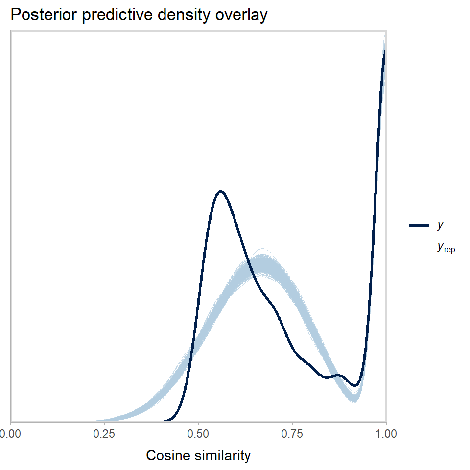

**Figure 2.** Posterior predictive density overlay for n=500 draws. Figure generated using [`R`](https://www.r-project.org/) version 4.4.1 (2024-06-14 ucrt)

```r
pp_check(mdl_null_similarity_simple, ndraws=500) + xlab('Cosine similarity') + ggtitle('Posterior predictive density overlay');
```

```
## Using all posterior draws for ppc type 'stat' by default.
## Using all posterior draws for ppc type 'stat' by default.
## Using all posterior draws for ppc type 'stat' by default.
```

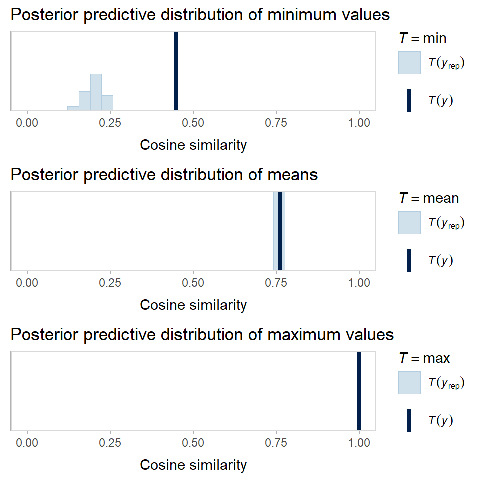

**Figure 3.** Posterior predictive distribution. Figure generated using [`R`](https://www.r-project.org/) version 4.4.1 (2024-06-14 ucrt)

```r
grid.arrange(pp_check(mdl_null_similarity_simple, type='stat', sta ='min') + xlab('Cosine similarity') + ggtitle('Posterior predictive distribution of minimum values') + xlim(0,1),
             pp_check(mdl_null_similarity_simple, type='stat', stat='mean') + xlab('Cosine similarity') + ggtitle('Posterior predictive distribution of means') + xlim(0,1),
             pp_check(mdl_null_similarity_simple, type='stat', stat='max') + xlab('Cosine similarity') + ggtitle('Posterior predictive distribution of maximum values') + xlim(0,1),
             ncol=1);
```

**Fixed effects**:

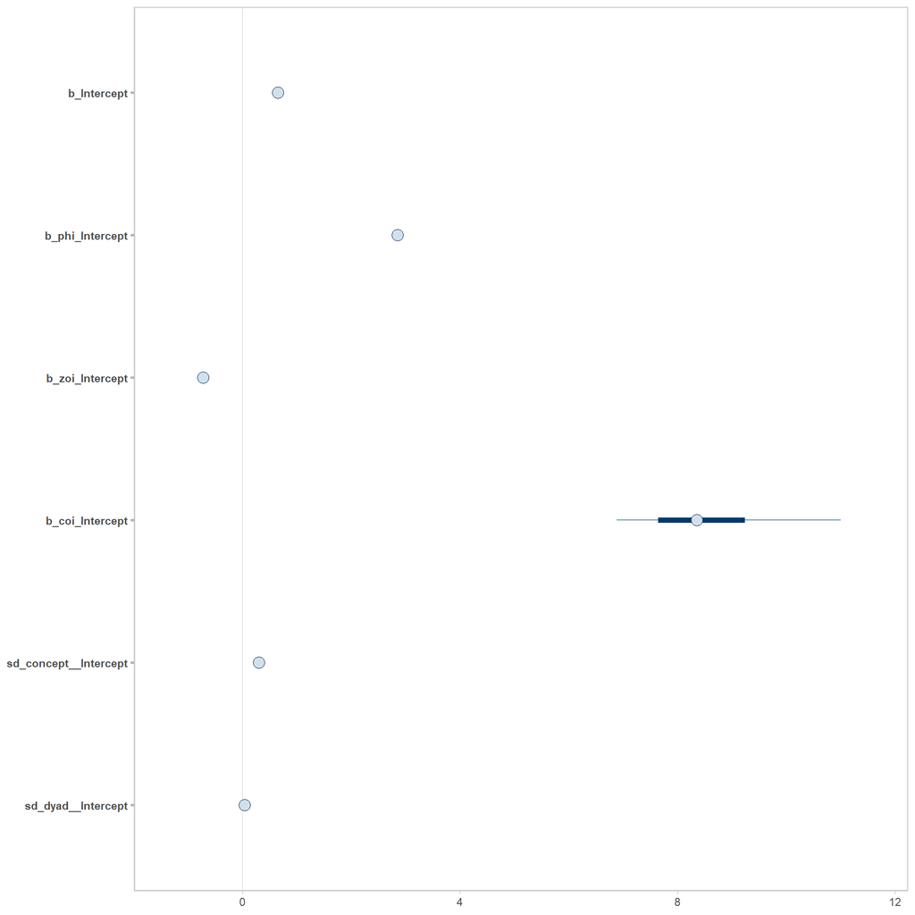

**Figure 4.** Fixed effects’ posterior distributions. Figure generated using [`R`](https://www.r-project.org/) version 4.4.1 (2024-06-14 ucrt)

```r
mcmc_plot(mdl_null_similarity_simple);
```

```r
back_transform_zoib(
  fixef(mdl_null_similarity_simple, dpar = "mu")["Intercept", "Estimate"],
  fixef(mdl_null_similarity_simple, dpar = "zoi")["Intercept", "Estimate"]
)
```

```
## [1] 0.7746826
```

Since our model is intercept‐only, we create a one‐row dummy data frame and add a constant y value. This avoids the computational overhead of using the full data while ensuring that the ggdist functions (which require a y aesthetic for horizontal plots) run without error.

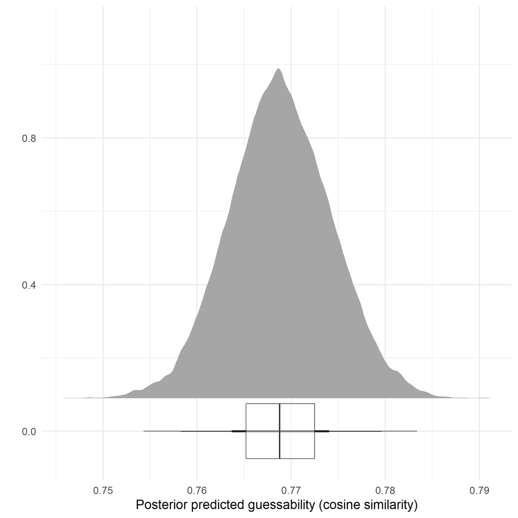

**Figure 5.** Posterior distribution of guessability. Figure generated using [`R`](https://www.r-project.org/) version 4.4.1 (2024-06-14 ucrt)

```r
# Create a one-row dummy data frame with a constant y value
df_dummy <- tibble(dummy = 1, y = 0)

# Generate posterior predictions on the response scale using our intercept-only model.
# We supply re_formula = NA so that predictions are made without replicating group-level structure.
df_dummy %>%
  add_epred_draws(mdl_null_similarity_simple, re_formula = NA, type = "response") %>%
  mutate(y = 0) %>%  # Provide a y aesthetic for horizontal plotting
  ggplot(aes(x = .epred, y = y)) +
  ggdist::stat_halfeye(
    adjust = 0.5,
    width = 0.6,
    .width = c(0.66, 0.95),
    justification = -0.1,
    point_colour = NA
  ) +
  geom_boxplot(
    aes(y = y),
    width = 0.15,
    outlier.shape = NA,
    alpha = 0.5,
    position = position_nudge(y = 0)
  ) +
  theme_minimal(base_size = 18) +
  labs(
    x = "Posterior predicted guessability (cosine similarity)",
    y = ""
  )
```

**Random effects**:

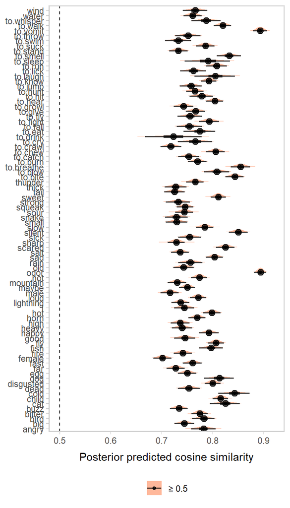

```r
grid.arrange(
  # 1 | concept:
  mdl_null_similarity_simple %>%
  spread_draws(b_Intercept, r_concept[concept]) %>%
  # Add the fixed intercept for mu to the concept-specific random effect:
  mutate(mu_concept = fixef(mdl_null_similarity_simple, dpar = "mu")["Intercept", "Estimate"] + r_concept) %>%
  # Back-transform to the original scale using the common inflation parameter from zoi:
  mutate(guessability = back_transform_zoib(mu_concept, fixef(mdl_null_similarity_simple, dpar = "zoi")["Intercept", "Estimate"])) %>%
  ggplot(aes(y = concept, x = guessability, fill = after_stat(x < 0.5))) +
  stat_halfeye(alpha = 0.75, point_interval = median_qi, .width = c(0.50, 0.95)) +
  scale_fill_manual(values = c("lightsalmon", "skyblue"),
                    name = NULL, labels = c("≥ 0.5", "< 0.5")) +
  geom_vline(xintercept = 0.5, linetype = "dashed") +
  #ggtitle("Posterior estimates of concept-level\ncosine similarity") +
  xlab("Posterior predicted cosine similarity") +
  ylab(NULL) +
    theme(legend.position="bottom"),
  nrow=1)
```

Get a general overview of the group-level effects.

| Random Effect | Estimate | Est.Error | Q2.5 | Q97.5 |
| --- | --- | --- | --- | --- |
| Intercept | 0.2982471 | 0.02532846 | 0.2532859 | 0.3524991 |

| Random Effect | Estimate | Est.Error | Q2.5 | Q97.5 |
| --- | --- | --- | --- | --- |
| Intercept | 0.0344352 | 0.01125735 | 0.009198192 | 0.05488744 |

There is a lot of variance across different concepts. But there is little variance across different dyads.

We can plot the variance across the concepts extracting draws.

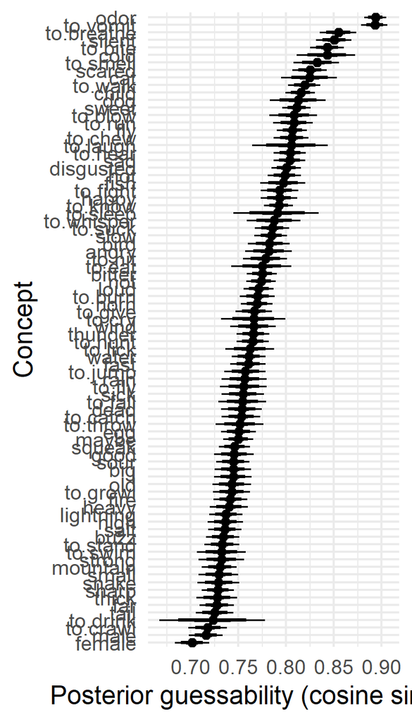

**Figure 7.** Posterior cosine similarity of concepts showing the median (dot), 50% (thick line), 80% (medium thick line), and 95% (thin lines) quantiles. Figure generated using [`R`](https://www.r-project.org/) version 4.4.1 (2024-06-14 ucrt)

```r
# 1 | concept
mdl_null_similarity_simple %>%
  spread_draws(r_concept[concept, dyad]) %>%
  # Combine the fixed intercept (mu) with the concept-specific random effect.
  mutate(mu_concept = fixef(mdl_null_similarity_simple, dpar = "mu")["Intercept", "Estimate"] + r_concept) %>%
  # Back-transform to the response scale using the common inflation parameter:
  mutate(guessability = back_transform_zoib(mu_concept, fixef(mdl_null_similarity_simple, dpar = "zoi")["Intercept", "Estimate"])) %>%
  median_qi(guessability, .width = c(0.5, 0.8, 0.95)) %>%
  ggplot(aes(x = guessability, y = fct_reorder(concept, guessability))) +
  geom_pointinterval(aes(xmin = .lower, xmax = .upper), position = position_dodge(width = 0.1)) +
  labs(
    x = "Posterior guessability (cosine similarity)",
    y = "Concept"
  ) +
  theme_minimal(base_size = 18)
```

To validate our model’s group-level estimates, we also plot the raw data. This plot shows the distribution of cosine similarity values for each concept using a half‐eye plot (which neatly displays medians and uncertainty intervals) and faceting by concept.

```r
df %>%
  filter(!is.na(cosine_similarity)) %>%
  group_by(concept) %>%
  median_qi(cosine_similarity, .width = c(0.5, 0.8, 0.95)) %>%
  ggplot(aes(x = cosine_similarity, y = fct_reorder(concept, cosine_similarity))) +
  geom_pointinterval(aes(xmin = .lower, xmax = .upper),
                     position = position_dodge(width = 0.1)) +
  labs(
    x = "Raw cosine similarity",
    y = "Concept"
  ) +
  theme_minimal(base_size = 18)
```

[output not shown]

**Interpretation**: Our simple ZOIB model for cosine similarity splits the data into two parts: a “beta” part (the regular responses) and an “inflation” part (responses that are exactly 1). The intercept for the beta component is estimated at 0.65 on the logit scale (95% credible interval [0.58, 0.72]). When we back–transform this using the inverse-logit function, it corresponds to an average cosine similarity of about 66% (roughly 64% to 67%) for the non-inflated responses. The zero–one inflation (zoi) intercept is estimated at –0.73 on the logit scale (95% CI [–0.77, –0.68]), which back–transforms to an inflation probability of about 32% (approximately 32% [31.6%, 33.6%]). This means that **about one–third of all responses are exactly 1**.

By combining these two parts—taking 32% of responses to be perfect (1) and the remaining 68% to have an average score of about 66%—the overall **expected cosine similarity is** roughly calculated as 0.324 × 1 + 0.676 × 0.657 ≈ 0.77 or **about 77%**.

Finally, the random effects show that there is moderate variability across concepts (SD ≈ 0.30 with a 95% CI of roughly [0.25, 0.35]) but very little variability across dyads (SD ≈ 0.03 with a 95% CI of [0.01, 0.05]).

In plain terms, among the “regular” responses the average score is about 66%, but because around one–third of responses are perfect, the overall **average similarity is boosted to about 77%**. This result means that, on average, participants’ nonverbal productions are quite effective, with a high proportion of responses achieving near–perfect expression.

## 4.2 Guess binary

Preregistered model:

`guessability_match ~ 1 + (1 | dyad/participant) + (1 | concept), family = bernoulli(link='logit')`

**Intercept-only model for binary outcome**

```r
mdl_null_binary <- readRDS(paste0(models, "mdl_null_binary.rds"))
```

Calculate R².

```
##     Estimate   Est.Error      Q2.5    Q97.5
## R2 0.2138749 0.006375742 0.2012669 0.226228
```

R^2 is 0.2138749 suggesting that 21.3874906% of the variance in the outcome variable are explained by the model. Generally, the model has a higher predictive power than the cosine similarity model.

**Diagnostic plots**:

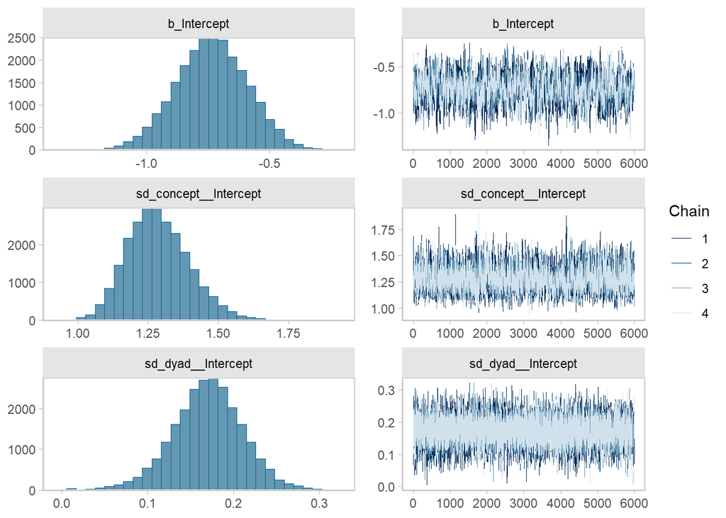

```r
plot(mdl_null_binary)
```

**Convergence**: All convergence diagnostics are good (Rhat ≤ 1.01).

```r
summary(mdl_null_binary)
```

```
##  Family: bernoulli
##   Links: mu = logit
## Formula: guess_binary ~ 1 + (1 | dyad) + (1 | concept)
##    Data: df (Number of observations: 8989)
##   Draws: 4 chains, each with iter = 10000; warmup = 4000; thin = 1;
##          total post-warmup draws = 24000
##
## Multilevel Hyperparameters:
## ~concept (Number of levels: 84)
##               Estimate Est.Error l-95% CI u-95% CI Rhat Bulk_ESS Tail_ESS
## sd(Intercept)     1.29      0.11     1.09     1.52 1.00     3138     6085
##
## ~dyad (Number of levels: 71)
##               Estimate Est.Error l-95% CI u-95% CI Rhat Bulk_ESS Tail_ESS
## sd(Intercept)     0.17      0.04     0.09     0.25 1.00     6814     5359
##
## Regression Coefficients:
##           Estimate Est.Error l-95% CI u-95% CI Rhat Bulk_ESS Tail_ESS
## Intercept    -0.74      0.15    -1.02    -0.46 1.01     1065     2373
##
## Draws were sampled using sampling(NUTS). For each parameter, Bulk_ESS
## and Tail_ESS are effective sample size measures, and Rhat is the potential
## scale reduction factor on split chains (at convergence, Rhat = 1).
```

```
## No divergences to plot.
```

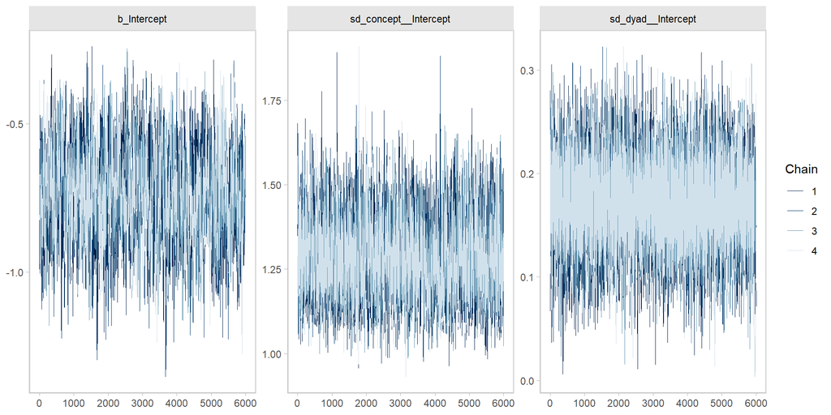

**Figure 9.** Trace of the fitting process. Figure generated using [`R`](https://www.r-project.org/) version 4.4.1 (2024-06-14 ucrt)

```r
mcmc_plot(mdl_null_binary, type="trace");
```

**Posterior predictive checks**: Looking good.

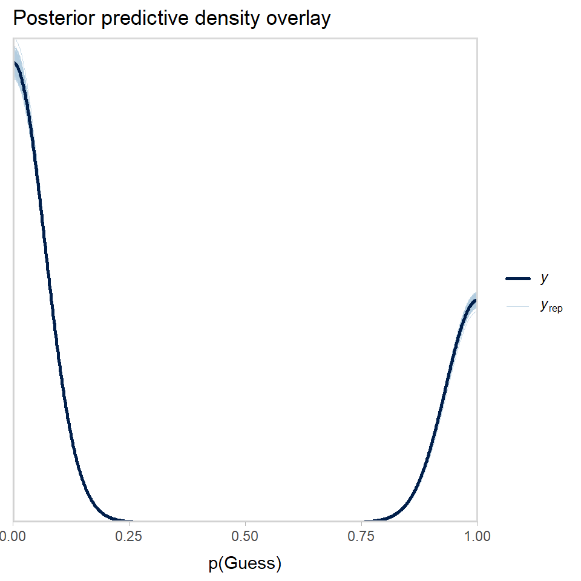

**Figure 10.** Posterior predictive density overlay for n=500 draws. Figure generated using [`R`](https://www.r-project.org/) version 4.4.1 (2024-06-14 ucrt)

```r
pp_check(mdl_null_binary, ndraws=500) + xlab('p(Guess)') + ggtitle('Posterior predictive density overlay');
```

```
## Using all posterior draws for ppc type 'stat' by default.
## Using all posterior draws for ppc type 'stat' by default.
## Using all posterior draws for ppc type 'stat' by default.
```

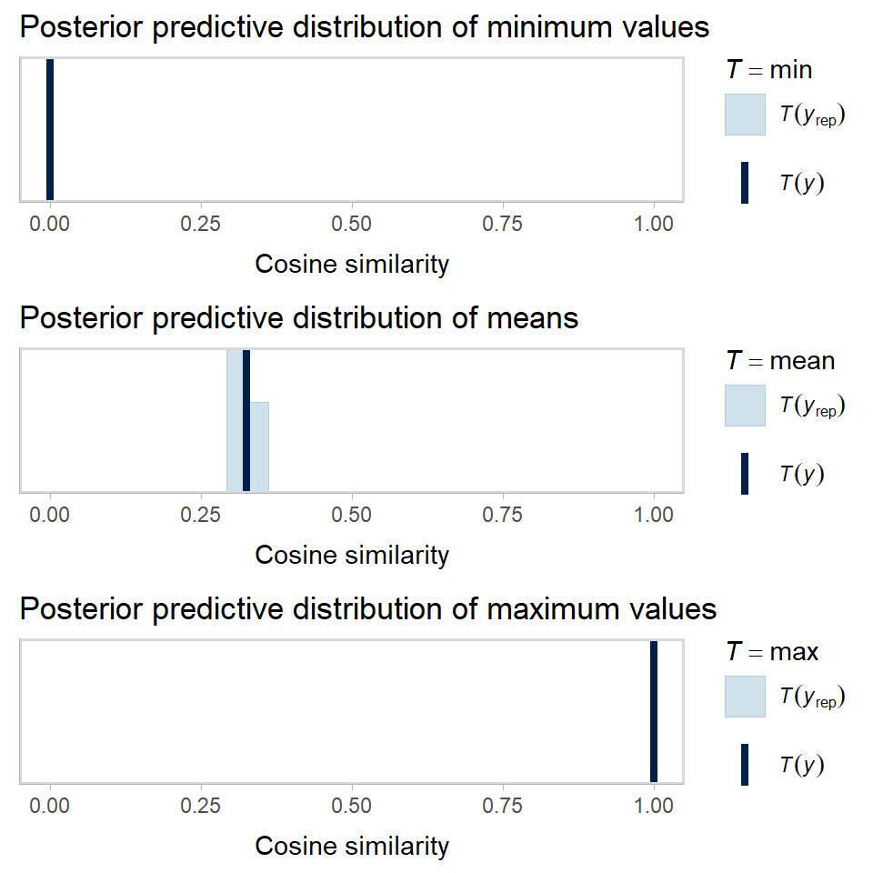

**Figure 11.** Posterior predictive distribution. Figure generated using [`R`](https://www.r-project.org/) version 4.4.1 (2024-06-14 ucrt)

```r
grid.arrange(pp_check(mdl_null_binary, type='stat', sta ='min') + xlab('Cosine similarity') + ggtitle('Posterior predictive distribution of minimum values') + xlim(0,1),
             pp_check(mdl_null_binary, type='stat', stat='mean') + xlab('Cosine similarity') + ggtitle('Posterior predictive distribution of means') + xlim(0,1),
             pp_check(mdl_null_binary, type='stat', stat='max') + xlab('Cosine similarity') + ggtitle('Posterior predictive distribution of maximum values') + xlim(0,1),
             ncol=1);
```

**Fixed effects**:

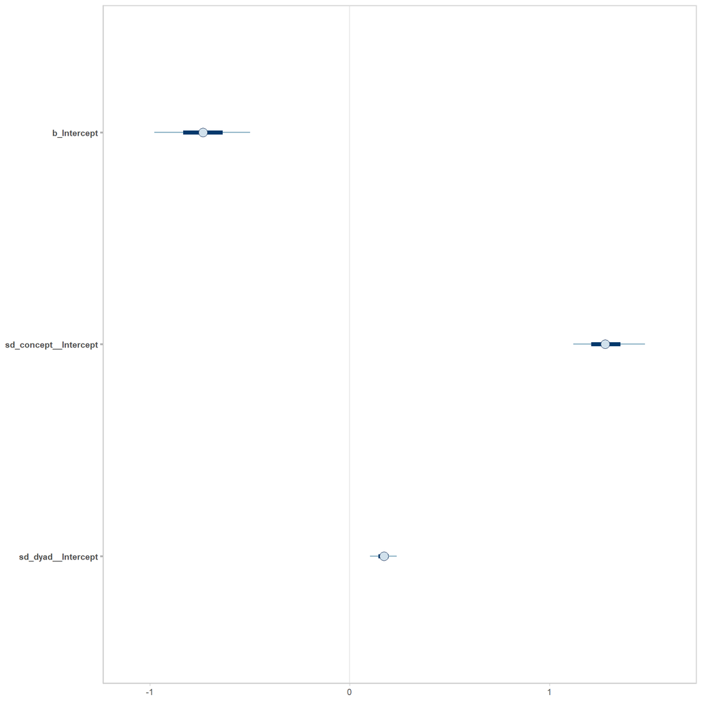

**Figure 12.** Fixed effects’ posterior distributions. Figure generated using [`R`](https://www.r-project.org/) version 4.4.1 (2024-06-14 ucrt)

```r
mcmc_plot(mdl_null_binary);
```